# Jitter Models

We investigate several different methods for modeling misalignment and jitter in SBF-SEM datasets

```python
# block for imports and fcns
from __future__ import print_function
import os

import cv2 as cv2
import matplotlib.pyplot as plt
import numpy as np
import tifffile as tif
from IPython.display import Image


def show_data(z, title, fignum):
    # Display a sample of the image
    fig  = plt.figure
    plt.imshow(z, cmap='gray')
    plt.title(title+': fig.'+ fignum)
    plt.show()
```

## Examining Jitter Types

First, we must look at two different misalignment types. The first is a global 'shift' in the data between z slices, seen best in the following samples from `test-volume.tif`. You cannot spot this type of misalignment by looking at the images themselves in isolation (fig 1 and fig 2), but becomes evident when you 'page through' the two z slices.

```
../../../../data/platelet
```

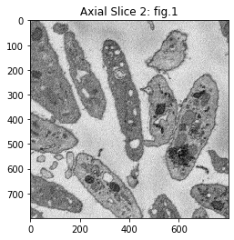

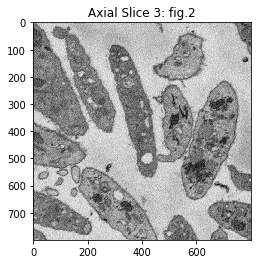

```python
# Root project directory relative to this notebook
lcimb_dir = os.path.join('..', '..', '..', '..')
# Use platelet data
data_dir = os.path.join(lcimb_dir, 'data/platelet')
print(data_dir)
image = tif.imread(os.path.join(data_dir, 'test-volume.tif'))
# print("Test Volume Shape - ", image.shape)

zslice_2 = image[1, :,:]
zslice_3 = image[2, :,:]
show_data(zslice_2, 'Axial Slice 2','1')
show_data(zslice_3, 'Axial Slice 3','2')
```

[figure not shown]

Many conventional image registration tools assume several things that tend not to be true for our dataset. First, many tools assume that you have the same 'image content' seen from two different angles or perspective, or you have two pictures of the same content which are misaligned from each other. Instead, our issue is more akin to a video stabilization problem. Furthurmore, in larger datasets, ie `full-volume.tif`, this misalignment isn't global. The top half of the image might feature this sort of distortion, whereas the bottom is okay. This insinuates a local approach to alignment modeling would be best suited for these larger volumes.

First, we will focus on jitter models for smaller volumes, such as those illustrated above in `test-volume.tif`. We try out different technqiues to align `test-volume.tif` in order to develop a model for jitter/misalignment that we can later apply to `train-volume.tif`. We will attempt to align z-slices 2 and 3

# Jitter Modeling

First, we will try use a warping transofrm to align the images. It uses the RANSAC algorithm on ORB (basically SIFT) features to compute a warping matrix, which we then apply to our misaligned image to generate an aligned image.

```python
MAX_MATCHES = 500
GOOD_MATCH_PERCENT = 0.15

def alignImagesWarp(im1, im2):

  # Convert images to grayscale
  im1Gray = cv2.cvtColor(im1, cv2.COLOR_BGR2GRAY)
  im2Gray = cv2.cvtColor(im2, cv2.COLOR_BGR2GRAY)

  # Detect ORB features and compute descriptors.
  orb = cv2.ORB_create(MAX_MATCHES)
  keypoints1, descriptors1 = orb.detectAndCompute(im1Gray, None)
  keypoints2, descriptors2 = orb.detectAndCompute(im2Gray, None)

  # Match features.
  matcher = cv2.DescriptorMatcher_create(cv2.DESCRIPTOR_MATCHER_BRUTEFORCE_HAMMING)
  matches = matcher.match(descriptors1, descriptors2, None)

  # Sort matches by score
  matches.sort(key=lambda x: x.distance, reverse=False)

  # Remove not so good matches
  numGoodMatches = int(len(matches) * GOOD_MATCH_PERCENT)
  matches = matches[:numGoodMatches]

  # Draw top matches
  imMatches = cv2.drawMatches(im1, keypoints1, im2, keypoints2, matches, None)
  cv2.imwrite("matches.jpg", imMatches)

  # Extract location of good matches
  points1 = np.zeros((len(matches), 2), dtype=np.float32)
  points2 = np.zeros((len(matches), 2), dtype=np.float32)

  for i, match in enumerate(matches):
    points1[i, :] = keypoints1[match.queryIdx].pt
    points2[i, :] = keypoints2[match.trainIdx].pt

  # Find homography
  h, mask = cv2.findHomography(points1, points2, cv2.RANSAC)

  # Use homography
  height, width, channels = im2.shape
  im1Reg = cv2.warpPerspective(im1, h, (width, height))

  return im1Reg, h, imMatches
```

We will also try applying an affine transformation, instead of a general warping transformation. This type of transfomation makes more sense, since the jitter pheomina observed is typically characterized by horizontal displacement or shearing, both of which are affine transformations. The method employed relies on measuring the correlation between the two images.

```python
def alignImagesAffine(im1, im2):
      # Convert images to grayscale
  im1Gray = cv2.cvtColor(im1, cv2.COLOR_BGR2GRAY)
  im2Gray = cv2.cvtColor(im2, cv2.COLOR_BGR2GRAY)

  im1Gray = cv2.bitwise_not(im1Gray)

  # Find size of image1
  sz = im1.shape

  # Define the motion model
  warp_mode = cv2.MOTION_AFFINE

  # Define 2x3 or 3x3 matrices and initialize the matrix to identity
  warp_matrix = np.eye(2, 3, dtype=np.float32)

  # Specify the number of iterations.
  number_of_iterations = 1000

  # Specify the threshold of the increment
  # in the correlation coefficient between two iterations
  termination_eps = 1

  # Define termination criteria
  criteria = (cv2.TERM_CRITERIA_EPS | cv2.TERM_CRITERIA_COUNT, number_of_iterations, termination_eps)

  # Run ECC algorithm to compute affine warp matrix
  (cc, warp_matrix) = cv2.findTransformECC(im1Gray, im2Gray, warp_matrix, warp_mode, criteria,None)

  im2_aligned = cv2.warpAffine(im2Gray, warp_matrix, (sz[1], sz[0]),
                                 flags=cv2.INTER_LINEAR + cv2.WARP_INVERSE_MAP,
                                 borderMode=cv2.BORDER_CONSTANT, borderValue=255)

  return im2_aligned, warp_matrix
```

```
Aligning images via Warp ...
Saving aligned image :  alignedWarp.tif
Estimated homography matrix for warping transform :
 [[-1.68271277e+00 -8.48478910e-01  8.49953566e+02]
 [-1.26073330e+00 -1.00851462e+00  7.55241118e+02]
 [-2.14600366e-03 -1.22254571e-03  1.00000000e+00]]
```

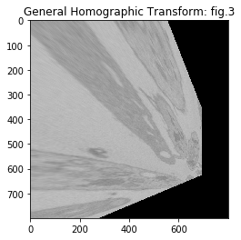

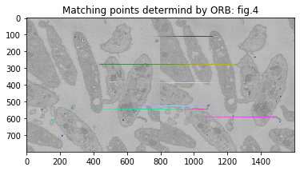

```
Aligning images via Affine Transform ...
Saving aligned image :  alignedAffine.tif
Estimated homography matrix for affine transform :
 [[1. 0. 0.]
 [0. 1. 0.]]
```

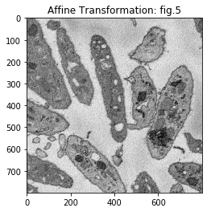

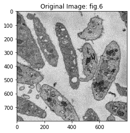

```python
imReference = cv2.imread(os.path.join(data_dir,'test-volume2.tif'), cv2.IMREAD_COLOR)
im = cv2.imread(os.path.join(data_dir,'test-volume3.tif'), cv2.IMREAD_COLOR)
im1Gray = cv2.cvtColor(im, cv2.COLOR_BGR2GRAY)

print("Aligning images via Warp ...")
# Registered image will be resotred in imReg.
# We will assume that zlice_2 is aligned and zslice_3 is misaligned
# The estimated homography will be stored in h.
imRegWarp, h, imMatches = alignImagesWarp(im, imReference)

outFilename = "alignedWarp.tif"
print("Saving aligned image : ", outFilename);
cv2.imwrite(outFilename, imRegWarp)

print("Estimated homography matrix for warping transform : \n",  h)
show_data(imRegWarp,"General Homographic Transform","3")
show_data(imMatches,"Matching points determind by ORB","4")

print("Aligning images via Affine Transform ...")
# Registered image will be resotred in imReg.
# We will assume that zlice_2 is aligned and zslice_3 is misaligned
# The estimated homography will be stored in h.
imRegAffine, h = alignImagesAffine(im, imReference)

outFilename = "alignedAffine.tif"
print("Saving aligned image : ", outFilename);
cv2.imwrite(outFilename, imRegAffine)

print("Estimated homography matrix for affine transform : \n",  h)
show_data(imRegAffine, "Affine Transformation","5")
show_data(im1Gray, "Original Image","6")
```

It is clear from fig.3 that using a general warping transformation is a poor way to model the types of deformations we see in the dataset.

The method of using an affine tranformation wasn't successful, since the algorithm under the hood assumed that the images were the same, so setting a reasonable threshold for the correlation in the two images caused the method to diverge. So, the only way to get the method to converge was by setting the threshold to 1, which forced the homography matrix to be the identity matrix, which is a useless model.

To find a working deformation model, I started to look into what was available in FIJI. Using the plugin 'Linear Stack Alignment with SIFT', I was able to successfully generate deformations similar to those observed in `full-volume.tif`. This indicated that using this 'Linear Stack Alignment with SIFT' plugin could yield a useful deformation model. However, because the documentation for the plugin is almost non-existant, I was unable to extract the affine transformations their implementation of SIFT calculated.

The FIJI implementation of SIFT actually works quite well on smaller volumes, like `test-volume.tif`. Below is the full, unaligned test volume

[figure not shown]

Below is the test volume that has been aligned via the FIJI SFIT extension

[figure not shown]

In the aligned volume, there is much less swaying, and there is much less jitter if you track one cell or feature as it 'moves' through the volume

In order to generate these affine transformation matricies, I wrote my own SIFT program (See `stack_align.py` and `registration.py`). It's certiantly not of the same quality as the FIJI SIFT plugin. I found that SIFT was very hard to stabilize, in that after applying it successeively to slices in a volume, the transformations effectively destroy the image, so I could only get 3-4 good transformation matricies in any one run. So, I ran SIFT several times, visually inspected the volumes to choose affine transormation matricies that looked reasonable. I then stored those matricies in order, so as to make sure that misalignment in subsequent volumes is correlated.

Below is the aligned `train-vol.tif`, and its unaligned counter part generated by applying these transformations I generated.

[figure not shown]

While this is a model, it isn't great. There is a lot more jitter in the model than there is in the actual dataset. This is due to the hard to control SIFT algorithm, which tended to take very extreme transformations.

# Remarks